# Билет 3

```python
import numpy as np
import matplotlib.pyplot as plt
import matplotlib
```

### Задача 1

#### Понятие числовой последовательности. Определения ограниченной и неограниченной, бесконечно большой и бесконечно малой последовательности. Примеры.

Числовая последовательность $ \{x_n\} $ - множество чисел $ \{x_1, x_2, \dots, x_n, \dots \} $, в котором наждому натуральному числу $ n $ поставленов соответствие какое-то вещественное число $ x_n $

Ограниченная последовательность - последовательность, для которой $ \exists A: \forall x \in \{x_n\} \ |x_n| \leqslant A $  
Неограниенная последовательность - оследовательность, для которой $ \forall A: \exists x \in \{x_n\} \ |x_n| > A $

Последовательность называется бесконечно большой, если $ \forall A \ \exists N(A): \forall n \geqslant N \ |x_n| > A $  
Последовательность называется бесконечно малой, если $ \forall \varepsilon \ \exists N(\varepsilon): \forall n \geqslant N \ |x_n| < \varepsilon $

Примеры:

$ x_n = n $ - бесконечно большая, неограниченная последовательность  
$ x_n = \frac{1}{n} $ - бесконечно малая, ограниченная последовательность

### Задача 2

#### Определение, свойства и график функции $ y=tg x $

Функция нечётная, периодическая ($ T = \pi $).

Возрастает на $ \mathbb{X} $

Функция непрерывна на $ \mathbb{X} $

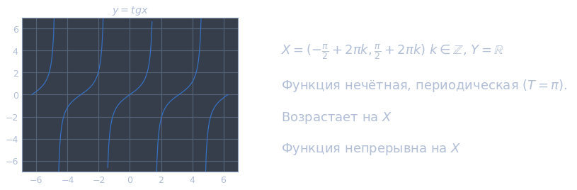

```python
x = np.linspace(- 2 * np.pi, 2 * np.pi, 200)
y = np.tan(x)
threshold = 10
y[y>threshold] = np.inf
y[y<-threshold] = np.inf

matplotlib.rcParams.update({'font.size': 18})

fig, axs = plt.subplots(1, 2, figsize=(12, 4))
axs[0].set_ylim([-7, 7])
axs[0].plot(x, y)
axs[0].set_title('$ y=tg x $')

axs[1].axis('off')
axs[1].text(0, 0.02, r"""
$ X = (-\frac{\pi}{2} + 2\pi k, \frac{\pi}{2} + 2\pi k) \ k \in \mathbb{Z} $, $ Y = \mathbb{R} $

Функция нечётная, периодическая ($ T = \pi $).

Возрастает на $ X $

Функция непрерывна на $ X $
""")
plt.show()
```

### Задача 3

Определение точной нижней грани числового множества $ \{x\} $

Число $ m^* $ называется точной нижней границей $ A $, если:

1. $ a \geqslant m^* \space \forall \space a \in A $
2. $ \forall x \in \mathbb{R}, x > m^*, \forall \space a' \in A \space \space a < x $

### Задача 4

Дать определение по Коши: $ \exists \space \lim\limits_{x \to -\infty} f(x) = b $

$ \lim\limits_{x \to -\infty} f(x) = b \Leftrightarrow \forall \varepsilon > 0 \ \exists \delta = \delta(\varepsilon) > 0 \ \forall x \in X: x < -\delta \Rightarrow |f(x) - b| < \varepsilon $

### Задача 5

#### Дать определение: $ \phi(x) \sim \psi(x), x \to a+0 $

Если $ \exists \lim\limits_{x \to a + 0} \frac{\phi(x)}{\psi(x)} = 1 $, то $ \phi(x) \sim \psi(x), x \to a + 0 $